# Juvenile snowshoe hare weight: exploratory report

Lucas Boyd

11/4/2021

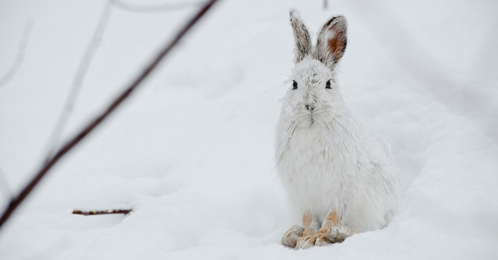

A lone snowshoe hare braves the winter conditions: *DeaShoots*

## 1. Introduction and Overview

Keilland Knut and their team conducted capture-recapture studies of snowshoe hares as part of the Long Term Ecological Research Program at the University of Alaska. The following report is an overview of the differences in weight among juvenile snowshoe hares in the Bonanza Creek Experimental Forest. First, total observations (number of juvenile hares trapped) are examined across each year of the study. Then, the difference in weight among male and female juvenile hares is examined. Finally, a linear regression model is used to understand the relationship between hind foot length and weight. This exploration will serve to help us better understand this important keystone species.

## 2. Data and Analyses

```r
hares <- read_csv(here("data", "bonanza_hares.csv")) %>%
  clean_names() %>%# cleaning names
  filter(age == "j") %>% # filtering for juveniles
  mutate(date = mdy(date)) %>% # converting date format
  mutate(year = year(date)) %>%  # creating a new year column
  mutate(sex = case_when( # changing names of observations
    sex == "f" ~ "Female",
    sex == "m" ~ "Male",))
```

## 3. Preliminary Results

### A. Annual observations of juvenile hares

```r
hares_by_year <- hares %>%
  count(year) # creating a subset for hare totals by year to explore the data
hares_by_year_mean <- mean(hares_by_year$n) # storing summary statistics
hares_by_year_max <- max(hares_by_year$n)
hares_by_year_min <- min(hares_by_year$n)
```

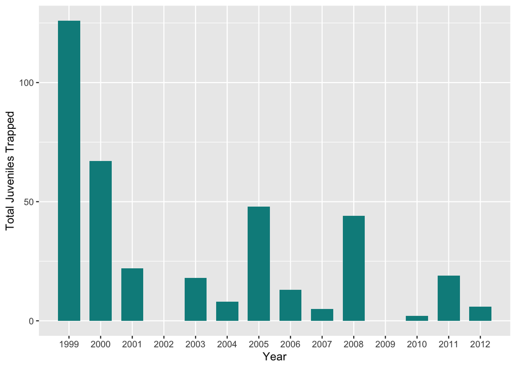

```r
ggplot(data = hares_by_year, aes(x = year, y = n)) +
  geom_col(fill = "cyan4", width = 0.7) + # creating a bar graph of trap counts
  labs(x = "Year", y = "Total Juveniles Trapped") +
  scale_x_discrete(limit = c(1999:2012)) + # manually putting ticks for x axis
  theme_grey()
```

**Fig. 1** shows total the total number of juvenile snowshoe hares trapped and observed each year across all sites.

As illustrated in figure 1, number of juvenile trappings were not consistent from year to year. The greatest number trapped was 126 in 1999, the first year of the study. In 2002 and 2009, there were no juvenile observations collected. The mean number of hares trapped by year was 31.5. While this appears to show a downward trend in juvenile hare population, it could also be a result of less effort put into data collection. Going forward, researchers should be consistent about how many traps are set out and how often they’re checked to ensure accurate representations of snowshoe hare populations.

### B. Weight comparison and descriptive statistics

```r
# group and summarize the data for use in the visual
hares_weight_by_site_summary <- hares %>%
  group_by(sex, grid) %>%
  summarize(
    mean_weight = mean(weight, na.rm = TRUE))
```

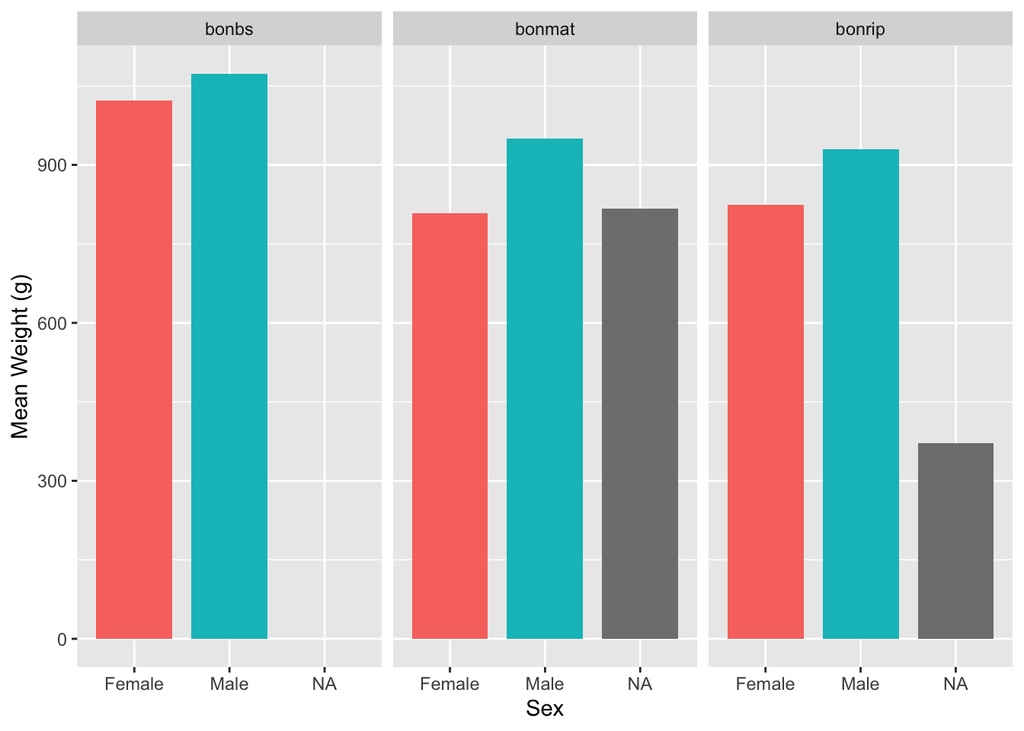

```r
# visualizing average hare weight by site and sex
ggplot(data = hares_weight_by_site_summary,
       aes(x = sex, y = mean_weight, fill = sex)) +
  geom_col(width = 0.8) +
  facet_wrap(~ grid) + # faceting by site
  labs(x = "Sex", y = "Mean Weight (g)") +
theme(legend.position = "none") +
  theme_grey() +
  theme(legend.position = "None") # removing the legend
```

**Fig. 2** compares the mean weight (g) of male and female juvenile snowshoe hares across the three collection sites. “NA” indicates that the sex was unspecified.

Across all three sites, male juvenile snowshoe hares had a higher mean weight (g) than females and juvenile hares with unspecified sex. Both mean female and mean male weight was the highest at site “bonbs”. This seems to show that juvenile male snowshoe hares tend to be heavier than females. There were no observations with unspecified sex at site “bonbs”.

### C. Juvenile hare weight difference analysis

**Table 1** Descriptive statistics (mean, standard deviation, sample size) of weight (g) of male and female juvenile snowshoe hares.

```r
hares_sex_table <- hares %>%
  filter(sex %in% c("Male", "Female")) %>%
  drop_na(weight) %>% # filtering out unspecified sexes and weights
  group_by(sex) %>% # grouping by sex
  summarize( # finding summary statistics
    mean_weight = round(mean(weight, na.rm = TRUE), 0),
    sd_weight = round(sd(weight, na.rm = TRUE), 0),
    sample_size = n())

hares_sex_table %>% # creating a stylized table with the stats
  kable(col.names = c("Sex",
                      "Mean Weight (g)",
                      "Standard Deviation (g)",
                      "Sample Size")) %>%
  kable_styling(bootstrap_options = "striped", full_width = FALSE)
```

| Sex | Mean Weight (g) | Standard Deviation (g) | Sample Size |
| --- | --- | --- | --- |
| Female | 855 | 292 | 197 |
| Male | 946 | 333 | 163 |

```r
# storing vectors of male and female weights to use in t test

weight_male <- hares %>% # storing male weights
  filter(sex == "Male") %>%
  drop_na(weight) %>%
  pull(weight)


weight_female <- hares %>% # storing female weights
  filter(sex == "Female") %>%
  drop_na(weight) %>%
  pull(weight)
```

```r
# running a t.test of the weights
weight_by_sex_t <- t.test(weight_male, weight_female)

# finding and storing the actual difference in means
sex_weight_mean_difference = mean(weight_by_sex_t$estimate[1]) -
  mean(weight_by_sex_t$estimate[2])

# finding and storing standard deviations for results
male_sd <- sd(weight_male)
female_sd <- sd(weight_female)

# finding and storing the effect size
sex_weight_effect_size <- cohen.d(weight_male, weight_female, na.rm = TRUE)
```

### D. Relationship between juvenile weight and hind foot length

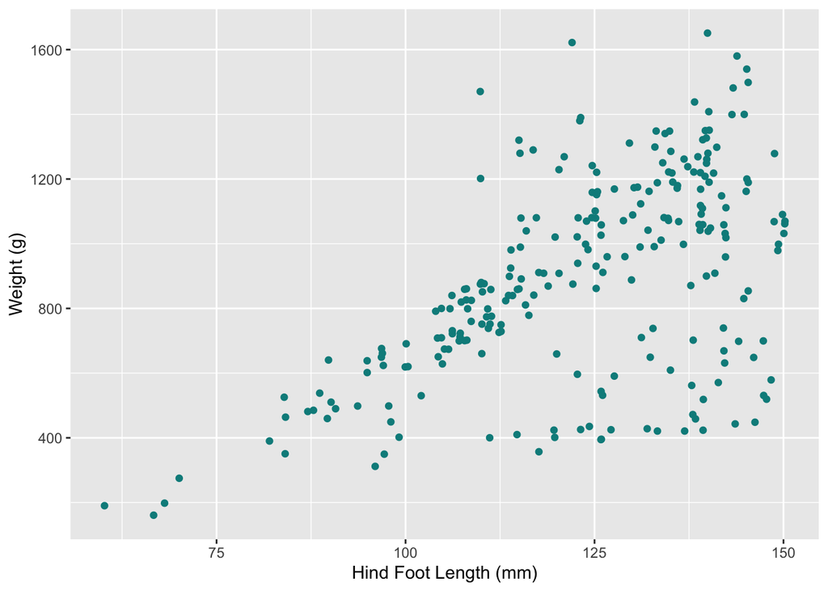

```r
# creating a visual of weight vs. hind foot length
ggplot(data = hares, aes(x = hindft, y = weight)) +
  geom_jitter(color = "cyan4", size = 1.5) +
  labs(x = "Hind Foot Length (mm)", y = "Weight (g)") +
  theme_grey()
```

**Fig. 3** examines the relationship between hind foot length (mm) and weight (g) in juvenile snowshoe hares, seeming to indicate a positive correlation between the two variables.

```r
# linear regression

hindft_weight_lm <- lm(weight ~ hindft, data = hares)

# tidy data frame of linear regression outputs
hindft_weight_lm_tidy <- tidy(hindft_weight_lm)

# getting model-wide measures of uncertainty
lm_glance <- glance(hindft_weight_lm)

# making it report-ready with equatiomatic
hindft_weight_lm_eq <- extract_eq(model = hindft_weight_lm, use_coefs = TRUE)

# finding pearson's R for this relationship
pearsons_r <- cor.test(hares$hindft, hares$weight)
```

The relationship between hind feet length and weight appears relatively linear in juvenile snowshoe hares. A simple linear regression model revealed that hind feet length significantly predicts weight (R<sup>2</sup>= 0.3, p <0.001), with an average slope of 9.52. This means that for every millimeter increase in hind foot length, we expect an average weight increase of 9.52g. Furthermore, hind feet length and weight are positively correlated (Pearson’s R = 0.55, p < 0.001). The resulting linear regression equation is as follows:
$$\operatorname{\widehat{weight}} = -279.34 + 9.52(\operatorname{hindft})$$

The R<sup>2</sup> value is small (0.3), so the linear regression model is only moderately adept at predicting weight from hind foot length. Additionally, based on the exploratory plots, the data appears to be heteroscedastic, with a greater variance in data as hind foot length increases. For this reason, I would not rely on a linear regression model alone to represent the relationship between hind foot length and weight in juvenile snowshoe hares.

## 5. Summary

Our preliminary results reveal the following:

- Total number of observations of snowshoe hares varies greatly year to year and appears to be declining. However, this could be explained by inconsistent data collection.
- Juvenile male snowshoe hares tend to weigh more on average than females.
- There appears to be a moderate positive correlation between juvenile snowshoe hare hind foot length and weight.

Next Steps:

- Compare the relationship between hind foot length and weight in the entire population of snowshoe hares, to see if there is more evidence of a positive correlation
- Apply multiple linear regression to model relationships between weight, sex, site, and age
- Compare observation statistics with data collection behaviors to better understand juvenile hare population trends

## 6. Citations

**Data Citation:** Kielland, K., F.S. Chapin, R.W. Ruess, and Bonanza Creek LTER. 2017. Snowshoe hare physical data in Bonanza Creek Experimental Forest: 1999-Present ver 22. Environmental Data Initiative. https://doi.org/10.6073/pasta/03dce4856d79b91557d8e6ce2cbcdc14 (Accessed 2021-11-05).